# DATA607 Predicting Fraud. Data in Context.

5/1/2017

## Background

In Social Selling, there are times when specific groups of people purposely decide to join a business opportunity with the intent of generating quick money before being detected by corporate.

This is particularly common when companies are young and don't have the capabilities or staff to catch fradulent behavior before it happens.

The goal is to predict potential fraud by taking into account specific variables from various tables including Orders, Recruiting History and Location in the Tree Structure.

## MSSQL and Picking Variables

The data to be analyzed is transactional data that lives in MSSQL for corporate.  
From there, other variables where generated from items found inside of this such as country, months in the business, and averages of specific variables month over month.

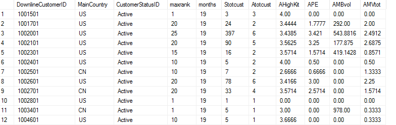

Figure 1. SQL Table.

## Open Connection to SQL and Store Data

```cpp
library(RODBC)

driver.name <- "SQL Server"
db.name <- "AndorraReporting"
host.name <- "404-sql1.vm.epicservers.com\\SQL1"
port <-""
server.name <- "SQL1"
user.name <-"Andorra_sa"
pwd <- "And@13579"
# Use a full connection string to connect to a SAMPLE database

AR <- odbcConnect("404-sql1.vm.epicservers.com", uid=user.name, pwd=pwd)
```

## Open Connection to SQL and Store Data

```cpp
Downline <- sqlQuery(AR, "
                   SELECT * FROM dbo.SVM
                   where CustomerStatusID <> 'Other'
                   ")

#data review
library(ggplot2)
qplot(APE, AHighKit, data=Downline, colour=CustomerStatusID, size=I(4))

odbcClose(AR)
```

## Show Comparison of Entry Level and Personally Enrolled

The following is a graphic showing those that were terminated due to fraud detection after the fact.

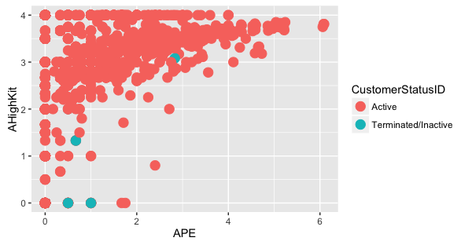

Figure 2. Comparison Between Entry Level and Personally Enrolled.

## Developing SVM to Attempt Prediction

The following R code helps determine if I can predict a fraud case by labelling them as terminated. The original data set had 34 cases of terminated but with the SVM model, we aren't able to predict them. They turn up as Active (no fraud).

```r
library(e1071)
attach(Downline)
Downline <- Downline[c(2:11)]
x <- subset(Downline, select=-CustomerStatusID)
y <- CustomerStatusID
svm_model <- svm(CustomerStatusID ~ ., data=Downline)
pred <- predict(svm_model,x)

head(table(pred,y))
```

```
##                      y
## pred                  Active Terminated/Inactive
##   Active                2187                  34
##   Terminated/Inactive      0                   0
```

## Summary

The model had 34 original terminate (fraud) cases which is 1.5% of the dataset. When using SVM to predict this it is unable to becasue in it's mind it has successfully predicted ~99% of the cases.

## Appendix A. SQL Part 1

```cpp
Getting Pertinent Variables
drop table #one
select DownlineCustomerID, c.MainCountry, c.CustomerStatusID,
    case
        when c.RankID is null then 0
        else c.RankID end 'RankID',
        datediff(month, CreatedDate, getdate()) 'months',
count(a.customerid) 'totcust', volume22 'HighKit', volume26 'PersEnroll',
volume86 'MBvol', volume87 'MVtot'
into #one
from dbo.enrollerdownline a
left join dbo.PeriodVolumes b
on a.customerid = b.customerid
left join dbo.customers c
on a.downlinecustomerid = c.customerid
where periodid = 7 and level >0 and DownlineCustomerID > 100000
group by DownlineCustomerID, c.MainCountry, c.CustomerStatusID, c.RankID, CreatedDate, volume22, volume26, volume86, volume87
```

## Appendix A. SQL Part 2

``` Create View for SVM in R

DROP VIEW dbo.SVM CREATE VIEW dbo.SVM AS select DownlineCustomerID, MainCountry, CustomerStatusID, max(rankid) 'maxrank', max(months) 'months', sum(totcust) 'Stotcust', avg(totcust) 'Atotcust', avg(HighKit) 'AHighKit', avg(PersEnroll) 'APE', avg(MBvol) 'AMBvol', avg(MVtot) 'AMVtot' FROM ( select DownlineCustomerID, case when c.MainCountry = '' then 'UN' else c.MainCountry end 'MainCountry', case when c.CustomerStatusID = 1 then 'Active' when c.CustomerStatusID in (2,6) then 'Terminated/Inactive' else 'Other' end CustomerStatusID, case when c.RankID is null then 0 else c.RankID end 'RankID', datediff(month, CreatedDate, getdate()) 'months', count(a.customerid) 'totcust', volume22 'HighKit', volume26 'PersEnroll', volume86 'MBvol', volume87 'MVtot' from dbo.enrollerdownline a left join dbo.PeriodVolumes b on a.customerid = b.customerid left join dbo.customers c on a.downlinecustomerid = c.customerid where periodid = 7 and level >0 and DownlineCustomerID > 100000 group by DownlineCustomerID, c.MainCountry, c.CustomerStatusID, c.RankID, CreatedDate, volume22, volume26, volume86, volume87 ) AS ONE group by downlinecustomerid, MainCountry, CustomerStatusID